# Types of Selection

Peter Ralph

2015-12-30

This document will go through several ways of implementing selection.

Here’s the habitat we’ll work with. Note that units are in meters, and the resolution of the raster is 100m. Since below we’re looking at selection for the *A* allele, we’ll start with about 100 copies of the *A* allele.

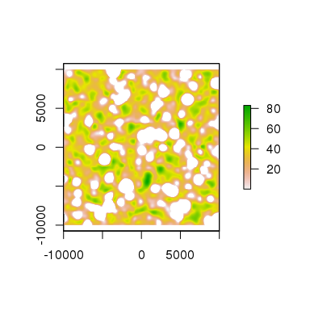

```r
pop <- make_population(
            habitat = random_habitat(),
            inaccessible.value = NA,
            uninhabitable.value = NA,
            genotypes = c("aa","aA","AA"),
            N = 0
        )
pop$N[,"aa"] <- rpois(nrow(pop$N),values(pop$habitat)[pop$habitable])
pop$N[,"aA"] <- rpois(nrow(pop$N),values(pop$habitat)[pop$habitable]*100/sum(values(pop$habitat),na.rm=TRUE))
pop$N[,"AA"] <- 0
plot(pop$habitat)
```

Here’s the basic, default demography, with population size regulation by means of competition for spots to germinate:

```r
basic.migr <- migration(
                    kern = "gaussian",
                    sigma = 300,
                    radius = 1000,
                    normalize = 1
             )
basic.demog <- demography(
        prob.seed = 0.05,
        fecundity = 200,
        prob.germination = vital(
                    function (N,...) {
                        out <- r0 / ( 1 + migrate(competition,x=rowSums(N))/K )
                        cbind( aa=out, aA=out, AA=out )
                    },
                    r0 = 0.4,
                    K = values(pop$habitat)[pop$habitable]/5,
                    competition = migration(
                                kern="gaussian",
                                sigma=200,
                                radius=400,
                                normalize=1
                        )
                ),
        prob.survival = 0.6,
        pollen.migration = basic.migr,
        seed.migration = basic.migr,
        genotypes = c("aa","aA","AA")
    )
```

# Directional selection on germination

First, we might make the probability of germination depend on the genotype:

```r
demog <- basic.demog
demog$prob.germination <- vital(
                    function (N,...) {
                        out <- r0 / ( 1 + migrate(competition,x=rowSums(N))/K )
                        cbind( aa=s[1]*out, aA=s[2]*out, AA=s[3]*out )
                    },
                    s = c(aa=1,aA=1.4,AA=1.4^2),
                    r0 = 0.4,
                    K = values(pop$habitat)[pop$habitable]/5,
                    competition = migration(
                                kern="gaussian",
                                sigma=200,
                                radius=400,
                                normalize=1
                        )
                )
```

This *increases* the carrying capacity of the *AA* genotypes, and so quickly leads to the *A* allele taking over.

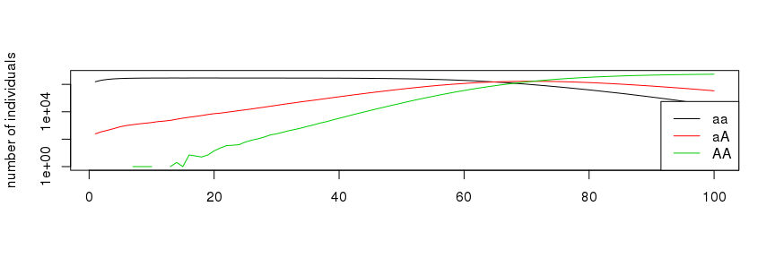

```r
demog <- setup_demography( demog, pop )
sim <- simulate_pop( pop, demog, times=seq(0,100,length.out=101),
                summaries=list( totals=function(N){colSums(N)} ) )
matplot(sim$summaries[["totals"]],type='l',lty=1, log='y', ylab="number of individuals")
legend("bottomright",lty=1,col=1:3,legend=pop$genotypes)
```

```r
plot(sim,pop,pause=FALSE)
```

[video not shown]

# Symmetric heterozygote disadvantage

Let’s mess with this a bit, creating an incompatibility:

```r
demog$prob.germination$s <- c( aa=1, aA=0.5, AA=1 )
```

So this looks nice, we’ll start with comparable numbers of both types:

```r
pop$N[,"aa"] <- rpois(nrow(pop$N),values(pop$habitat)[pop$habitable]/3)
pop$N[,"aA"] <- rpois(nrow(pop$N),values(pop$habitat)[pop$habitable]/3)
pop$N[,"AA"] <- rpois(nrow(pop$N),values(pop$habitat)[pop$habitable]/3)
```

Here’s what this looks like:

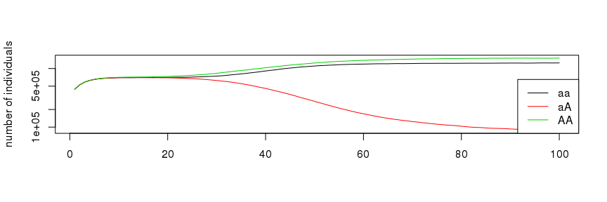

```r
demog <- setup_demography( demog, pop )
sim <- simulate_pop( pop, demog, times=seq(0,100,length.out=101),
                summaries=list( totals=function(N){colSums(N)} ) )
matplot(sim$summaries[["totals"]],type='l',lty=1, log='y', ylab="number of individuals")
legend("bottomright",lty=1,col=1:3,legend=pop$genotypes)
```

```r
plot(sim,pop,pause=FALSE)
```

[video not shown]

# Local adaptation by probability of death

Now, let’s set up a selective gradient where *a* is selected on one side, and *A* is selected on the other.

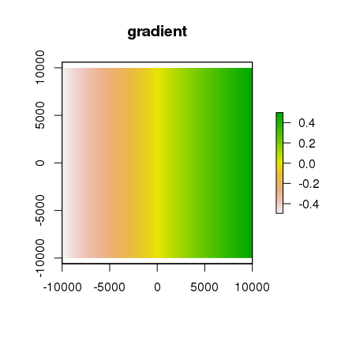

```r
grad <- pop$habitat
values(grad) <- colFromCell(grad,1:ncell(grad))/ncol(grad) - 0.5
plot(grad,main="gradient")
```

```r
demog <- basic.demog
demog$prob.seed <- 0.01
demog$prob.survival <- vital(
                    function (N,...) {
                        out <- s0 / ( 1 + migrate(competition,x=rowSums(N))/K )
                        cbind( aa=(1-s)*out, aA=out, AA=(1+s)*out )
                    },
                    s0 = 0.6,
                    s = values(grad)[pop$habitable],
                    K = values(pop$habitat)[pop$habitable]/3,
                    competition = migration(
                                kern="gaussian",
                                sigma=200,
                                radius=400,
                                normalize=1
                        )
                )
```

Here’s what this looks like:

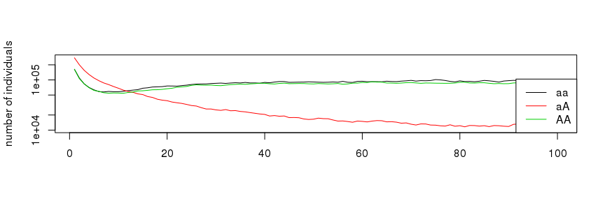

```r
demog <- setup_demography( demog, pop )
sim <- simulate_pop( pop, demog, times=seq(0,100,length.out=101),
                summaries=list( totals=function(N){colSums(N)} ) )
matplot(sim$summaries[["totals"]],type='l',lty=1, log='y', ylab="number of individuals")
legend("bottomright",lty=1,col=1:3,legend=pop$genotypes)
```

```r
plot(sim,pop,pause=FALSE)
```

[video not shown]

# Soft selection

The situations above have different carrying capacities for different genotypes. If we switch to soft selection, the overall carrying capacity is constant, regardless of the composition of genotypes.

```r
demog <- basic.demog
demog$prob.germination <- vital(
                    function (N,...) {
                        P <- (N[,2]/2+N[,3])
                        P[P>0] <- P[P>0]/(rowSums(N)[P>0])
                        out <- r0 / ( 1 + migrate(competition,x=rowSums(N))/K )
                        out <- cbind( aa=(1-P*s)*out, aA=out, AA=(1+(1-P)*s)*out )
                        if (any(out<0)||any(out>1)||any(!is.finite(out))) { browser () }
                        out
                    },
                    s = 0.4,
                    r0 = 0.4,
                    K = values(pop$habitat)[pop$habitable]/5,
                    competition = migration(
                                kern="gaussian",
                                sigma=200,
                                radius=400,
                                normalize=1
                        )
                )
```

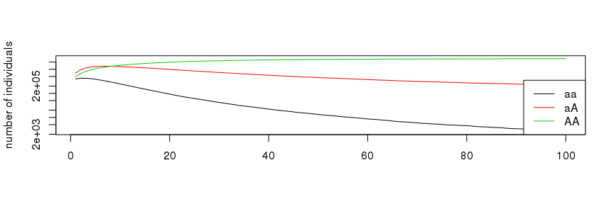

```r
demog <- setup_demography( demog, pop )
sim <- simulate_pop( pop, demog, times=seq(0,100,length.out=101),
                summaries=list( totals=function(N){colSums(N)} ) )
matplot(sim$summaries[["totals"]],type='l',lty=1, log='y', ylab="number of individuals")
legend("bottomright",lty=1,col=1:3,legend=pop$genotypes)
```

```r
plot(sim,pop,pause=FALSE)
```

[video not shown]